# MachineLearningProject

Alfredo A Hernandez

September 13, 2014

The goal of the project is to predict the manner in which they did the exercise. This is the “classe” variable in the training set. You may use any of the other variables to predict with. You should create a report describing how you built your model, how you used cross validation, what you think the expected out of sample error is, and why you made the choices you did. You will also use your prediction model to predict 20 different test cases.

Reproducibility: Due to security concerns with the exchange of R code, your code will not be run during the evaluation by your classmates. Please be sure that if they download the repo, they will be able to view the compiled HTML version of your analysis.

Load libraries, download data, read into R and extract relevant information:

```r
library(caret)
library(rattle)
directoryName <- "/Users/aah3/Alfredo/Developer/R/Data/Coursera/"
getwd()
```

```
## [1] "/Users/aah3/Alfredo/Developer/R/Code"
```

```r
setwd(directoryName)

fileSource <- "http://groupware.les.inf.puc-rio.br/har"
if(!file.exists("mlTrain.csv")){
  fileTrain <- "https://d396qusza40orc.cloudfront.net/predmachlearn/pml-training.csv"
  download.file(fileTrain,destfile=paste(directoryName,"mlTrain.csv",sep=""),method="curl")
  }

if(file.exists("mlTest.csv")){
  fileTest <- "https://d396qusza40orc.cloudfront.net/predmachlearn/pml-testing.csv"
  download.file(fileTest,destfile=paste(directoryName,"mlTest.csv",sep=""),method="curl")
  }

list.files()
```

```
##  [1] "cameras.csv"                    "communities.csv"
##  [3] "housingIdaho.csv"               "hw1_data.csv"
##  [5] "MachineLearningProject.knit.md" "mlTest.csv"
##  [7] "mlTest01.csv"                   "mlTrain.csv"
##  [9] "mlTrain01.csv"                  "ngap.xlsx"
## [11] "pml-testing.csv"                "pml-training.csv"
## [13] "sbuxPrices.csv"                 "specdata"
```

```r
dateDownloaded <- date()

if(file.exists("mlTrain.csv"))
  train <- read.csv("mlTrain.csv",header=T,as.is=T,fill=T,na.strings="")

if(file.exists("mlTest.csv"))
  test <- read.csv("mlTest.csv",header=T,as.is=T,fill=T,na.strings="")

iNum <- rep(F,ncol(train))
for(i in seq_along(iNum)) if( class(train[,i])=="numeric" | class(train[,i])=="integer" ) iNum[i] <- T
iNum[length(iNum)] <- T # add 'classe'
# head(train[,iNum],1)
train <- train[,iNum]
test <- test[,iNum]
train$classe <- factor(train$classe)
#test$classe <- factor(test$classe)
```

See information about train set:

```r
names(train)
```

```
##  [1] "X"                    "raw_timestamp_part_1" "raw_timestamp_part_2"
##  [4] "num_window"           "roll_belt"            "pitch_belt"
##  [7] "yaw_belt"             "total_accel_belt"     "gyros_belt_x"
## [10] "gyros_belt_y"         "gyros_belt_z"         "accel_belt_x"
## [13] "accel_belt_y"         "accel_belt_z"         "magnet_belt_x"
## [16] "magnet_belt_y"        "magnet_belt_z"        "roll_arm"
## [19] "pitch_arm"            "yaw_arm"              "total_accel_arm"
## [22] "gyros_arm_x"          "gyros_arm_y"          "gyros_arm_z"
## [25] "accel_arm_x"          "accel_arm_y"          "accel_arm_z"
## [28] "magnet_arm_x"         "magnet_arm_y"         "magnet_arm_z"
## [31] "roll_dumbbell"        "pitch_dumbbell"       "yaw_dumbbell"
## [34] "total_accel_dumbbell" "gyros_dumbbell_x"     "gyros_dumbbell_y"
## [37] "gyros_dumbbell_z"     "accel_dumbbell_x"     "accel_dumbbell_y"
## [40] "accel_dumbbell_z"     "magnet_dumbbell_x"    "magnet_dumbbell_y"
## [43] "magnet_dumbbell_z"    "roll_forearm"         "pitch_forearm"
## [46] "yaw_forearm"          "total_accel_forearm"  "gyros_forearm_x"
## [49] "gyros_forearm_y"      "gyros_forearm_z"      "accel_forearm_x"
## [52] "accel_forearm_y"      "accel_forearm_z"      "magnet_forearm_x"
## [55] "magnet_forearm_y"     "magnet_forearm_z"     "classe"
```

```r
table(train$classe)
```

```
##
##    A    B    C    D    E
## 5580 3797 3422 3216 3607
```

# Partition sets into Training and Testing.

In addition use four different categories to train data: belt, arm, dumbbell and forearm.

```r
inTrain <- createDataPartition(y=train$classe,p=0.7,list=F)
training <- train[inTrain,]
testing <- train[-inTrain,]
dim(training); dim(testing)
```

```
## [1] 13737    57
```

```
## [1] 5885   57
```

```r
# colnames(training)
namesList <- strsplit(names(train)[],"_")

namesPred <- c("belt","arm","dumbbell","forearm")
xx <- list("belt"=data.frame(), "arm"=data.frame(), "dumbbell"=data.frame(), "forearm"=data.frame())
```

# Fit models

Fit three different models: m1, m2 and m3, with methods rpart, rpart2 and ctree, respectively. Verify in-sample and out-of-sample predictive power.

```r
for( jj in seq_along(namesPred) ){
  datax <- data.frame()
  outx <- data.frame()

  ix <- rep(F,ncol(train))
  for(i in seq_along(namesList)) if( any(namesList[[i]] %in% namesPred[jj]) | any(namesList[[i]]=="classe") ) ix[i] <- T
  trainx <- training[,ix]
  testx <- testing[,ix]
  outOfSample <- test[,ix]
  #table(training$classe[inTrain])
  #table(training[,ix[1]])

  # m1
  modFit1 <- train(classe~., method="rpart",data=trainx) #
  # train
  modelPred1 <- predict(modFit1,newdata=trainx)
  datax <- rbind(datax,postResample(modelPred1, trainx$classe))
  # cm <- confusionMatrix(modelPred,reference=trainx$classe); cm$overall
  # sensitivity(modelPred, trainx$classe)
  # test
  modelPred1 <- predict(modFit1,newdata=testx)
  datax <- rbind(datax,postResample(modelPred1, testx$classe))
  # out-of-sample
  modelOutOfSample1 <- predict(modFit1,newdata=outOfSample)
  outx <- rbind(outx, (modelOutOfSample1))

  # m2
  modFit2 <- train(classe~., method="rpart2",data=trainx) #
  # train
  modelPred2 <- predict(modFit2,newdata=trainx)
  datax <- rbind(datax,postResample(modelPred2, trainx$classe))
  # test
  modelPred2 <- predict(modFit2,newdata=testx)
  datax <- rbind(datax,postResample(modelPred2, testx$classe))
  # out-of-sample
  modelOutOfSample2 <- predict(modFit2,newdata=outOfSample)
  outx <- rbind(outx, (modelOutOfSample2))
  #print(modelOutOfSample2)

  # m3
  modFit3 <- train(classe~., method="ctree",data=trainx) #
  # train
  modelPred3 <- predict(modFit3,newdata=trainx)
  datax <- rbind(datax,postResample(modelPred3, trainx$classe))
  # test
  modelPred3 <- predict(modFit3,newdata=testx)
  datax <- rbind(datax,postResample(modelPred3, testx$classe))
  # out-of-sample
  modelOutOfSample3 <- predict(modFit3,newdata=outOfSample)
  outx <- rbind(outx, (modelOutOfSample3))
  #print(modelOutOfSample3)

  colnames(datax) <- c("Accuracy","Kappa")
  rownames(datax) <- c("rpartTrain","rpartTest","rpart2Train","rpart2Test","ctreeTrain","ctreeTest")
  colnames(outx) <- 1:ncol(outx)
  rownames(outx) <- c("rpart","rpart2","ctree")
  xx[[jj]] <- list(Pred=datax,Out=outx)
}
```

# Print and plot results:

```r
print(xx)
```

```
## $belt
## $belt$Pred
##             Accuracy  Kappa
## rpartTrain    0.3950 0.1700
## rpartTest     0.3864 0.1567
## rpart2Train   0.6698 0.5811
## rpart2Test    0.6649 0.5750
## ctreeTrain    0.8495 0.8094
## ctreeTest     0.7730 0.7128
##
## $belt$Out
##        1 2 3 4 5 6 7 8 9 10 11 12 13 14 15 16 17 18 19 20
## rpart  1 1 1 1 1 5 1 1 1  1  1  1  1  1  1  1  1  1  1  1
## rpart2 2 1 2 4 2 5 4 2 4  1  2  1  2  1  5  5  1  2  1  2
## ctree  2 1 2 4 2 5 4 4 4  1  2  3  2  1  5  5  1  2  2  1
##
##
## $arm
## $arm$Pred
##             Accuracy  Kappa
## rpartTrain    0.4075 0.2575
## rpartTest     0.3930 0.2391
## rpart2Train   0.4191 0.2712
## rpart2Test    0.4051 0.2535
## ctreeTrain    0.7845 0.7268
## ctreeTest     0.6583 0.5666
##
## $arm$Out
##        1 2 3 4 5 6 7 8 9 10 11 12 13 14 15 16 17 18 19 20
## rpart  3 1 1 1 4 4 4 4 1  1  1  4  4  1  2  4  3  2  3  2
## rpart2 3 1 1 1 4 4 4 5 1  1  1  4  5  1  2  4  3  2  3  2
## ctree  2 1 2 1 4 5 2 2 1  1  2  5  2  1  2  5  1  2  5  2
##
##
## $dumbbell
## $dumbbell$Pred
##             Accuracy  Kappa
## rpartTrain    0.3838 0.1695
## rpartTest     0.3913 0.1794
## rpart2Train   0.5137 0.3616
```

[output cut: 11 more lines]

```
## $forearm
## $forearm$Pred
##             Accuracy  Kappa
## rpartTrain    0.3852 0.2016
## rpartTest     0.3806 0.1969
## rpart2Train   0.4325 0.2613
## rpart2Test    0.4311 0.2602
## ctreeTrain    0.8257 0.7793
## ctreeTest     0.7358 0.6652
##
## $forearm$Out
##        1 2 3 4 5 6 7 8 9 10 11 12 13 14 15 16 17 18 19 20
## rpart  3 1 3 1 4 3 3 4 1  1  3  3  3  1  3  4  1  4  4  3
## rpart2 4 1 3 1 2 3 4 2 1  1  3  3  3  1  3  2  1  4  4  3
## ctree  2 1 2 1 1 3 4 2 1  1  5  3  5  1  2  5  1  2  4  2
```

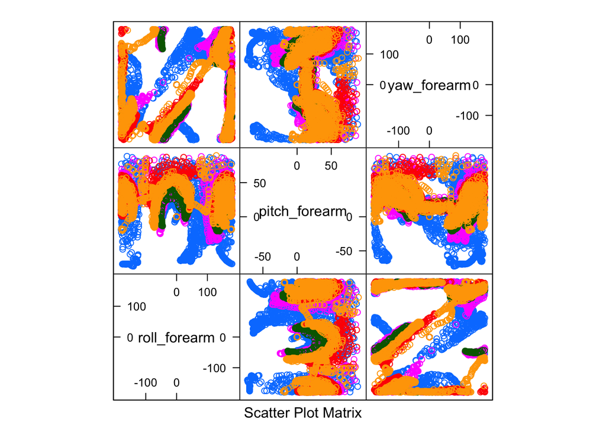

```r
featurePlot(x=trainx[,c(1,2,3)],y=trainx$class, plot="pairs")
```

```r
#featurePlot(x=trainx[,-14],y=trainx$class, plot="pairs")
#qq <- qplot(roll_forearm,classe,data=trainx)
#qq+geom_smooth(method='lm',formula=y~x)
```

# Train classe table:

```r
table(train$classe)
```

```
##
##    A    B    C    D    E
## 5580 3797 3422 3216 3607
```